# Exercício Xadrez

Um grupo de enxadresistas possui um conjunto de partidas armazenados como imagens e deseja criar um sistema para extrair as jogadas de cada partida para análise. Esse grupo deseja saber o movimento feito em cada rodada, ou seja, a peça movida da casa $x$ para a casa $y$. O grupo já tem programado a estrutura que deseja utilizar e que já foi colocado no arquivo "chess/chess.py". Este arquivo contém as seguintes classes:

- **ChessSquare**: Classe que representa uma casa do tabuleiro do Xadrez.
- Atributos
- **piece_name:** String de identificação da peça.
- **x:** Índice horizontal da peça no tabuleiro (0 ... 7)
- **y:** Índice vertical da peça no tabuleiro (0 ... 7)
- **Move**: Classe que representa uma jogada
- Atributos
- **image_filepath:** caminho do arquivo de imagem da jogada.
- **piece_start:** ChessSquare da peça antes da jogada.
- **piece_stop:** ChessSquare da peça depois da jogada.
- **Chessboard:** Classe que representa o tabuleiro de xadrez.
- Atributos
- **board:** vetor de ChessSquare, que armazema todas as casas do tabuleiro de xadrez.
- **template:** matriz que representa o tabuleiro em seu estado inicial.
- Métodos
- **_init_board:** Método que inicializa o tabuleiro com as posições iniciais de cada peça.
- **set_piece:** recebe uma string (piece_name) e coloca essa string na posição ("x", "y") do tauleiro. Onde piece_name é qualquer string de identificação de peça válido ou a string vazia "" (representa casa vazia).
- **print_board:** Método que imprime o tabuleiro no console com string de identificação para cada casa. (Uso para debug).
- **get_flat_board:** Método que retorna o tabuleiro como uma lista de ChessSquare, utilizando uma varredura de cima para baixo, da esquerda para direita.
- **Game:** Classe que representa uma partida de Xadrez
- Atributos
- **moves:** Lista de jogadas (objetos tipo Move) utilizado para armazenar as jogadas onde moves[i] representa a jogada i, moves[0] é a primeira jogada e moves[len(moves) - 1] é a última jogada.
- Métodos
- **add_move:** Adiciona uma jogada na posição len(moves) e aumenta o tamanho de moves em 1.

É pedido que seja implementado a função **analyze_chess_game** localizada no arquivo "chess/analyze.py", que recebe um diretorio (no caso "images/chess") contendo as imagens das jogadas númeradas de $1$ a $n$, todas do tipo ".png" (i.e. "images/chess/5.png" corresponde a imagem da jogada 5) e retorne um objeto Game com todas as jogadas armazenadas em seu atributo $moves$.

As imagens nomeadas com números ímpares são jogadas de peça branca e números pares de peça preta e a imagem "0.png" é a posição inicial do tabuleiro (sempre será a mesma imagem), cada casa possui dimensões 60x60 pixels, as casas escuras têm intensidade $80$ e as casas claras, intensidade $180$. As peças pretas têm intensidade $0$ e as peças brancas $255$. Os identificadores das peças são definidos abaixo:

- **P**: Pawn (Peão)
- **N**: Knight (Cavalo)
- **B**: Bishop (Bispo)
- **Q**: Queen (Rainha)
- **K**: King (Rei)

Dentro da classe *ChessSquare*, no atributo *piece_name*, a string de identificação de peças recebe a abreviação descrita acima, mais uma letra "W"(White) para peças brancas e "B"(black) para peças pretas, além disso, mais um número de identificação, caso exista mais de uma mesma peça (e.g., "NB1" é o cavalo preto número 1, note que existem 2 cavalos pretos; "PW5" é o peão branco número 5, note que existem 8 peãos de cada cor). Além disso, a string de identificação de peças pode ser vazia para indicar que a casa do tabuleiro está vazia.

A configuração inicial do tabuleiro é como segue.

|  | 0 | 1 | 2 | 3 | 4 | 5 | 6 | 7 |
| --- | --- | --- | --- | --- | --- | --- | --- | --- |
| 0 | RB1 | NB1 | BB1 | QB | KB | BB2 | NB2 | RB2 |
| 1 | PB1 | PB2 | PB3 | PB4 | PB5 | PB6 | PB7 | PB8 |
| 2 |  |  |  |  |  |  |  |  |
| 3 |  |  |  |  |  |  |  |  |
| 4 |  |  |  |  |  |  |  |  |
| 5 |  |  |  |  |  |  |  |  |
| 6 | PW1 | PW2 | PW3 | PW4 | PW5 | PW6 | PW7 | PW8 |
| 7 | RW1 | NW1 | BW1 | QW | KW | BW2 | NW2 | RW2 |

A cada nova imagem, seu algoritmo deve registrar em um objeto *Move*, no atributo *piece_start*, um objeto *ChessSquare*, com a seguintes informações:

- string de identificação da peça movida;
- a posição inicial da peça movida (posição da peça movida na jogada anterior)

e no atributo *piece_stop*, um objeto *ChessSquare*, com a seguintes informações:

- a string vazia, se a peça não capturou nenhuma peça adversária, ou identificação da peça capturada, caso contrário;
- a posição da peça depois da jogada conforme imagem sendo analisada.

Além disso, no atributo *image_filepath*, o caminho do arquivo da imagem sendo analisada. Finalmente, o objeto *Move* deve ser armazenado no objeto *Game*.

Teste seu código com nesse ipython notebook. O resultado esperado de seu ipython notebook está no arquivo "view_game.html" (Note que seu código será testado com outro conjunto de imagens). Lembrando que você deve utilizar os algoritmos visto em aula para resolver esse problema. Fique à vontade em acrescentar novas classes e funções que achar necessário. Para fazer perguntas ou comentários, utilize o forum do PACA ou email do monitor.

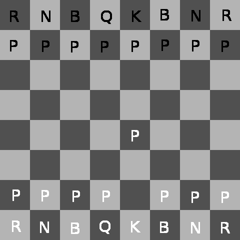

```
PW5 moves from (6, 4) to (4, 4)
```

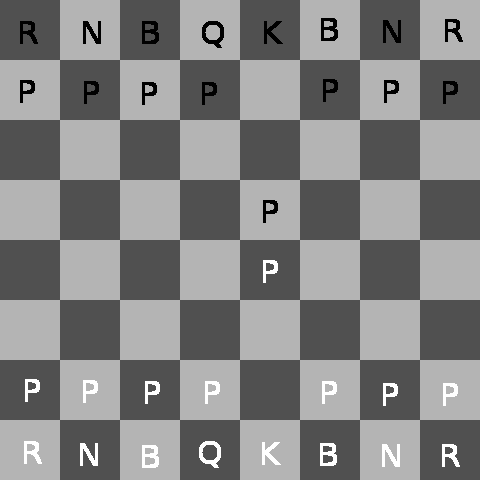

```
PB5 moves from (1, 4) to (3, 4)
```

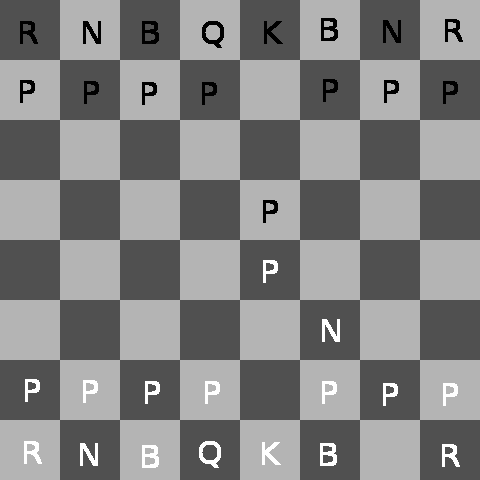

```
NW2 moves from (7, 6) to (5, 5)
```

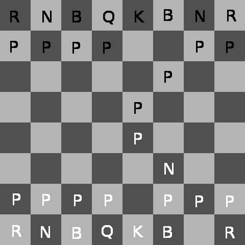

```
PB6 moves from (1, 5) to (2, 5)
```

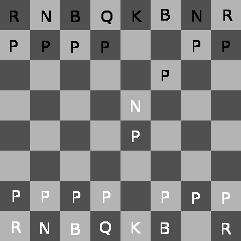

```
NW2 moves from (5, 5) to (3, 4) and captures PB5
```

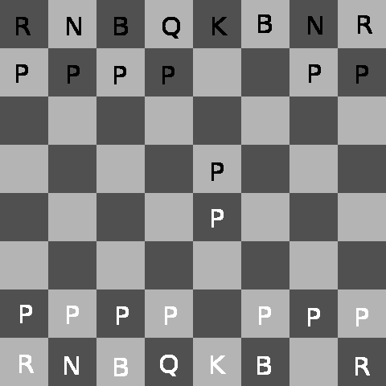

```
PB6 moves from (2, 5) to (3, 4) and captures NW2
```

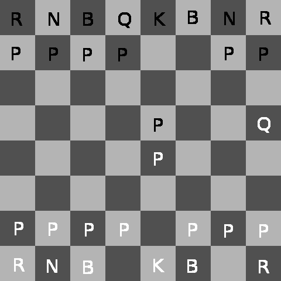

```
QW moves from (7, 3) to (3, 7)
```

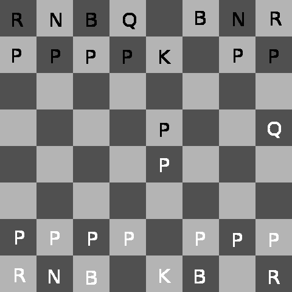

```
KB moves from (0, 4) to (1, 4)
```

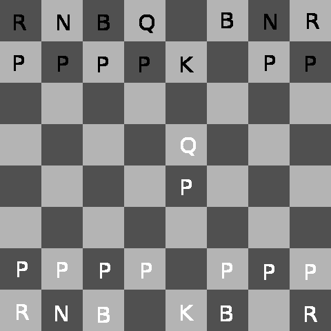

```
QW moves from (3, 7) to (3, 4) and captures PB6
```

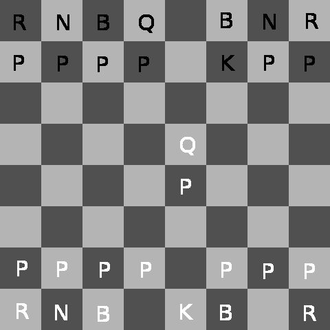

```
KB moves from (1, 4) to (1, 5)
```

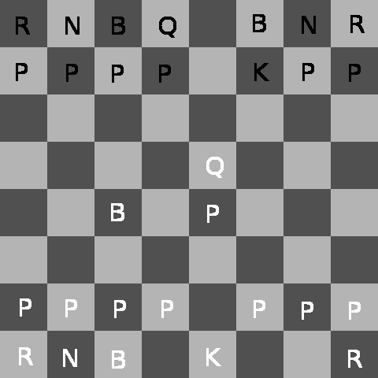

```
BW2 moves from (7, 5) to (4, 2)
```

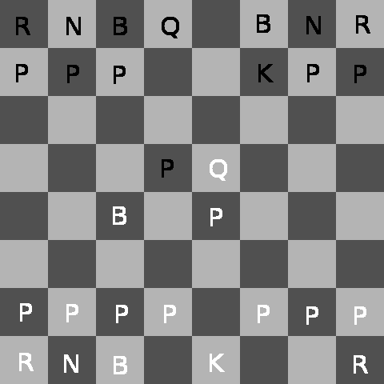

```
PB4 moves from (1, 3) to (3, 3)
```

[15 more figures not shown]

```
RW2 moves from (7, 7) to (3, 7) and captures PB8
```

```python
from IPython.display import Image, display
from chess.analyse import analyze_chess_game

game = analyze_chess_game("images/chess")


for move in game.moves:
        pstart = move.piece_start
        pstop = move.piece_stop
        text = pstart.piece_name + " moves from " + str((pstart.x, pstart.y))
        text += " to " + str((pstop.x, pstop.y))

        if pstop.piece_name is not "":
            text += " and captures " + pstop.piece_name
        text += "\n"
        display(Image(filename=move.image_filepath))
        print(text)
```